[figure not shown]

# About Dataset

## Overview

Zomato has an average of **17.5 million monthly transacting customers** for its food delivery business. Additionally, the **average monthly active food delivery restaurant partners** on Zomato's platform have also increased by **8.7% year-on-year**, growing from **208,000** to **226,000**.

This dataset provides insights into Zomato's food delivery operations, including restaurant types, customer preferences, votes, ratings, and approximate costs for two people. Through analyzing this data, we can uncover key trends in online ordering, customer behavior, and restaurant popularity.

IMPORTING LIBRARIES

```python
import pandas as pd
import numpy as np
import seaborn as sns
import matplotlib.pyplot as plt
import warnings
warnings.filterwarnings('ignore')
```

```python
df = pd.read_csv(r"E:\CodeBasic\Zomato data .csv")     # before put r -- row string , text path ke under convert ho jayega
df.head(5)
```

|  | name | online_order | book_table | rate | votes | approx_cost(for two people) | listed_in(type) |
| --- | --- | --- | --- | --- | --- | --- | --- |
| 0 | Jalsa | Yes | Yes | 4.1/5 | 775 | 800 | Buffet |
| 1 | Spice Elephant | Yes | No | 4.1/5 | 787 | 800 | Buffet |
| 2 | San Churro Cafe | Yes | No | 3.8/5 | 918 | 800 | Buffet |
| 3 | Addhuri Udupi Bhojana | No | No | 3.7/5 | 88 | 300 | Buffet |
| 4 | Grand Village | No | No | 3.8/5 | 166 | 600 | Buffet |

```python
df.shape
```

```
(148, 7)
```

```python
dict_counts={}
for i in df.columns:
    dict_counts[i]=df[i].value_counts().shape[0]

pd.DataFrame(dict_counts,index=['Unique']).T.style.background_gradient(cmap='bwr')
```

|  | Unique |
| --- | --- |
| name | 145 |
| online_order | 2 |
| book_table | 2 |
| rate | 20 |
| votes | 90 |
| approx_cost(for two people) | 18 |
| listed_in(type) | 4 |

```python
df.info()
```

```
<class 'pandas.core.frame.DataFrame'>
RangeIndex: 148 entries, 0 to 147
Data columns (total 7 columns):
 #   Column                       Non-Null Count  Dtype
---  ------                       --------------  -----
 0   name                         148 non-null    object
 1   online_order                 148 non-null    object
 2   book_table                   148 non-null    object
 3   rate                         148 non-null    object
 4   votes                        148 non-null    int64
 5   approx_cost(for two people)  148 non-null    int64
 6   listed_in(type)              148 non-null    object
dtypes: int64(2), object(5)
memory usage: 8.2+ KB
```

```python
df.describe()
```

|  | votes | approx_cost(for two people) |
| --- | --- | --- |
| count | 148.000000 | 148.000000 |
| mean | 264.810811 | 418.243243 |
| std | 653.676951 | 223.085098 |
| min | 0.000000 | 100.000000 |
| 25% | 6.750000 | 200.000000 |
| 50% | 43.500000 | 400.000000 |
| 75% | 221.750000 | 600.000000 |
| max | 4884.000000 | 950.000000 |

PREPROCESSING

```python
df.isnull().sum()
```

```
name                           0
online_order                   0
book_table                     0
rate                           0
votes                          0
approx_cost(for two people)    0
listed_in(type)                0
dtype: int64
```

```python
df.duplicated().sum()
```

```
0
```

```python
# Remove the '/5' from the 'rate' column and convert to float

df['rate'] = df['rate'].str.replace('/5', '').astype(float)
```

```python
df
```

|  | name | online_order | book_table | rate | votes | approx_cost(for two people) | listed_in(type) |
| --- | --- | --- | --- | --- | --- | --- | --- |
| 0 | Jalsa | Yes | Yes | 4.1 | 775 | 800 | Buffet |
| 1 | Spice Elephant | Yes | No | 4.1 | 787 | 800 | Buffet |
| 2 | San Churro Cafe | Yes | No | 3.8 | 918 | 800 | Buffet |
| 3 | Addhuri Udupi Bhojana | No | No | 3.7 | 88 | 300 | Buffet |
| 4 | Grand Village | No | No | 3.8 | 166 | 600 | Buffet |
| ... | ... | ... | ... | ... | ... | ... | ... |
| 143 | Melting Melodies | No | No | 3.3 | 0 | 100 | Dining |
| 144 | New Indraprasta | No | No | 3.3 | 0 | 150 | Dining |
| 145 | Anna Kuteera | Yes | No | 4.0 | 771 | 450 | Dining |
| 146 | Darbar | No | No | 3.0 | 98 | 800 | Dining |
| 147 | Vijayalakshmi | Yes | No | 3.9 | 47 | 200 | Dining |

148 rows × 7 columns

```python
df.info()
```

```
<class 'pandas.core.frame.DataFrame'>
RangeIndex: 148 entries, 0 to 147
Data columns (total 7 columns):
 #   Column                       Non-Null Count  Dtype
---  ------                       --------------  -----
 0   name                         148 non-null    object
 1   online_order                 148 non-null    object
 2   book_table                   148 non-null    object
 3   rate                         148 non-null    float64
 4   votes                        148 non-null    int64
 5   approx_cost(for two people)  148 non-null    int64
 6   listed_in(type)              148 non-null    object
dtypes: float64(1), int64(2), object(4)
memory usage: 8.2+ KB
```

EXPLORATORY DATA ANALYSIS

## 1) What type of restaurant do the majority of customers order from?

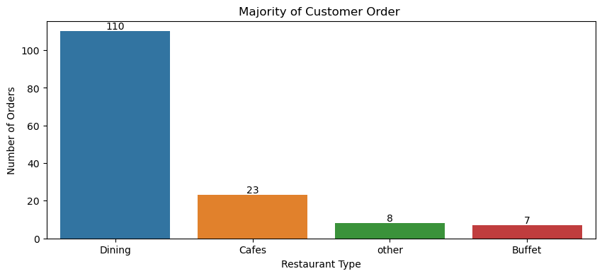

```python
type_counts = df['listed_in(type)'].value_counts()

plt.figure(figsize=(10, 4))
ax = sns.barplot(x=type_counts.index, y=type_counts.values)

plt.title('Majority of Customer Order ')
plt.xlabel('Restaurant Type')
plt.ylabel('Number of Orders')

for bars in ax.containers:
    ax.bar_label(bars)

plt.show()
```

**INSIGHT :**

- The majority of customers prefer ordering from **Dining** restaurants, with a total of **110** orders.
- **Cafes** follow as the second most popular type, with **23** orders.
- **Other** types of restaurants have **8** orders.
- **Buffet** restaurants are the least preferred with **7** orders.

## 2) How many votes has each type of restaurant received from customers?

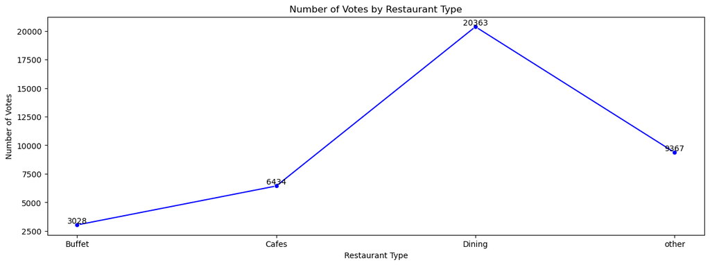

```python
votes_by_type = df.groupby('listed_in(type)')['votes'].sum()

plt.figure(figsize=(15, 5))
ax = sns.lineplot(x=votes_by_type.index, y=votes_by_type.values, marker='o', color='b')

plt.title('Number of Votes by Restaurant Type')
plt.xlabel('Restaurant Type')
plt.ylabel('Number of Votes')


for i, value in enumerate(votes_by_type.values):
    ax.text(i, value, str(value), ha='center', va='bottom')

plt.show()
```

**INSIGHT**

- The majority of votes are received by **Dining** restaurants, with a total of **20,363** votes.
- **Other** types of restaurants follow with **9,367** votes.
- **Cafes** have **6,434** votes.
- **Buffet** restaurants have the fewest votes, with **3,028** votes.

## 3) What are the ratings that the majority of restaurants have received?

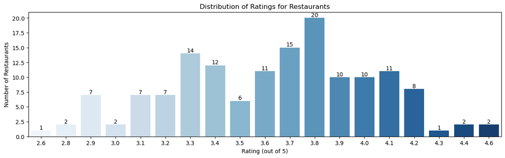

```python
ratings_count = df['rate'].value_counts().sort_index()

plt.figure(figsize=(15, 4))
ax = sns.barplot(x=ratings_count.index, y=ratings_count.values, palette='Blues')

plt.title('Distribution of Ratings for Restaurants')
plt.xlabel('Rating (out of 5)')
plt.ylabel('Number of Restaurants')

for i, value in enumerate(ratings_count.values):
    ax.text(i, value, str(value), ha='center', va='bottom')

plt.show()
```

**INSIGHT**

- The majority of restaurants have received a rating of **3.8**, which is the most frequent rating with **20** occurrences. This indicates that the average customer satisfaction level is relatively high but not exceptional.
- Additionally, ratings of **3.7** and **3.3** are also common, suggesting a general concentration of ratings in the mid to upper range of the scale.
- Most restaurants are rated between **3.3** and **4.1**, with **3.8** being the peak, reflecting a generally positive but varied level of customer satisfaction.

## 4) Zomato has observed that most couples order most of their food online. What is their average spending on each order?

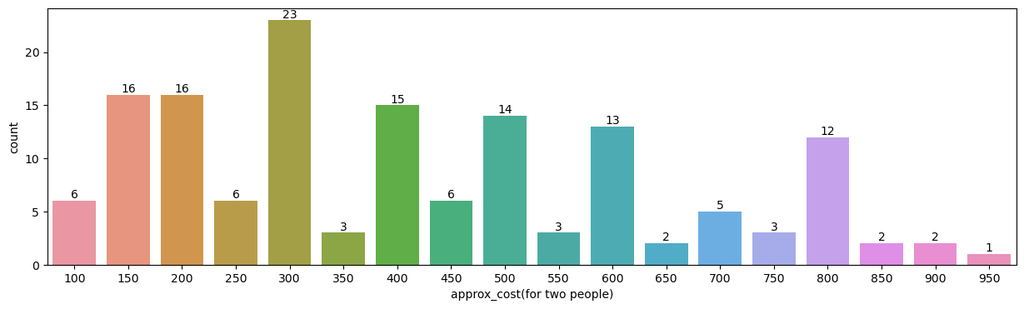

```python
plt.figure(figsize=(15, 4))
ax=sns.countplot(x=df['approx_cost(for two people)'])

for bars in ax.containers:
    ax.bar_label(bars)
```

**INSIGHT**

- The majority of couples spend around **300 rupees** on their food orders, with **23 occurrences** at this price point.
- The next most common spending amounts are **200 rupees** and **150 rupees**, each with **16 occurrences**, followed by orders costing **400 rupees** with **15 occurrences**.
- Most couples prefer affordable dining options, as the majority of the spending falls in the range of **200 to 500 rupees** per order.
- This suggests that Zomato can focus on promoting special offers for restaurants with meal options priced between **200 to 500 rupees** to attract more couples who prefer ordering online.

## 5) Which mode (online or offline) has received the maximum rating?

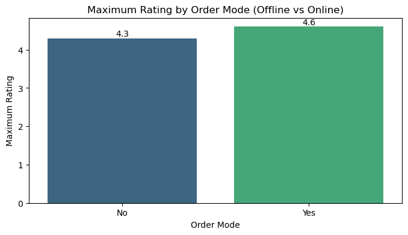

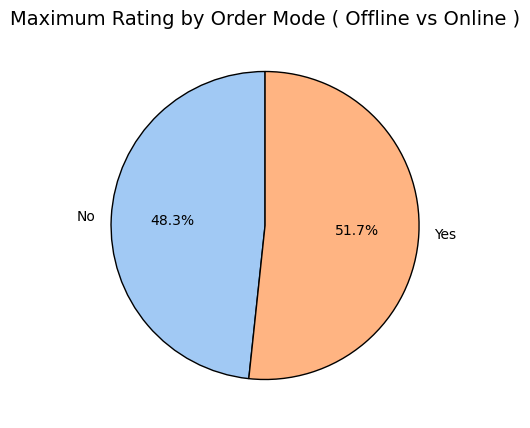

```python
max_rating_by_mode = df.groupby('online_order')['rate'].max()

plt.figure(figsize=(8, 4))
ax = sns.barplot(x=max_rating_by_mode.index, y=max_rating_by_mode.values, palette='viridis')

plt.title('Maximum Rating by Order Mode (Offline vs Online)')
plt.xlabel('Order Mode')
plt.ylabel('Maximum Rating')

for bars in ax.containers:
    ax.bar_label(bars, label_type='edge')

plt.show()


plt.figure(figsize=(8, 5))
colors = sns.color_palette('pastel')
plt.pie(max_rating_by_mode.values, labels=max_rating_by_mode.index, autopct='%1.1f%%', startangle=90, colors=colors, wedgeprops={'edgecolor': 'black'})

plt.title('Maximum Rating by Order Mode ( Offline vs Online )', fontsize=14)

plt.show()
```

**INSIGHT**

- Online orders have received the highest rating of **4.6 (51.7%)**, indicating a strong customer preference and satisfaction when ordering online.
- Offline orders, while still well-rated, have received a slightly lower maximum rating of **4.3(48.3%)**.
- This suggests that Zomato's online ordering system is meeting customer expectations more effectively, and future efforts could focus on further enhancing the offline experience to bridge the gap.

## 6) Which type of restaurant received more offline orders, so that Zomato can provide those customers with some good offers?

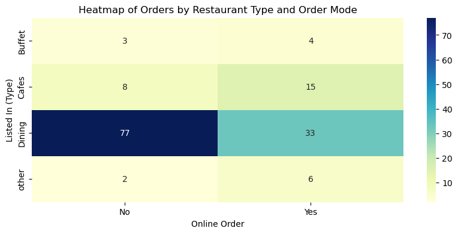

```python
pivot_table = df.pivot_table(index='listed_in(type)', columns='online_order', aggfunc='size', fill_value=0)

plt.figure(figsize=(10, 4))
sns.heatmap(pivot_table, annot=True, cmap="YlGnBu", fmt='d')

plt.title("Heatmap of Orders by Restaurant Type and Order Mode")
plt.xlabel("Online Order")
plt.ylabel("Listed In (Type)")
plt.show()
```

**INSIGHT**

- **Dining restaurants** received significantly more offline orders, with **77** offline orders compared to only **33** online orders.
- This indicates that customers prefer placing orders in person at dining restaurants, making them a great target for offline offers and promotions.
- Cafes, on the other hand, have a higher proportion of online orders, suggesting a different customer behavior for these types of establishments.

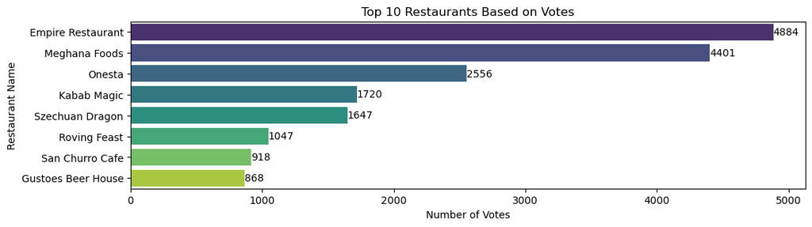

```python
top_voted = df.sort_values(by='votes', ascending=False).head(10)
plt.figure(figsize=(12, 3))
ax = sns.barplot(x='votes', y='name', data=top_voted, palette='viridis')

for bars in ax.containers:
    ax.bar_label(bars, label_type='edge')

plt.title('Top 10 Restaurants Based on Votes')
plt.xlabel('Number of Votes')
plt.ylabel('Restaurant Name')
plt.show()
```

## 8) Top 10 Restaurants Based on Ratings

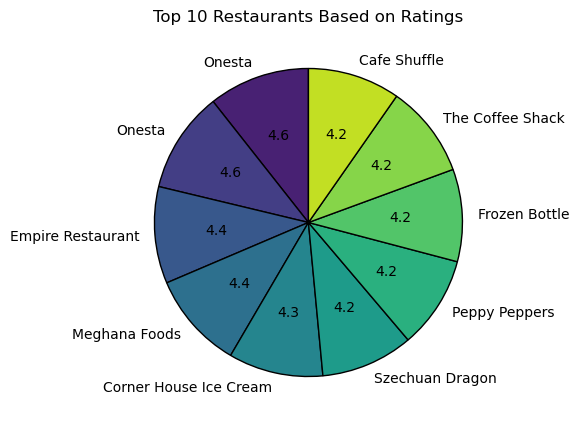

```python
top_rated = df.sort_values(by='rate', ascending=False).head(10)

plt.figure(figsize=(8, 5))
colors = sns.color_palette('viridis', len(top_rated))  # Use the 'viridis' color palette

plt.pie(top_rated['rate'], labels=top_rated['name'], autopct=lambda p: '{:.1f}'.format(p * sum(top_rated['rate']) / 100), startangle=90, colors=colors, wedgeprops={'edgecolor': 'black'})

plt.title('Top 10 Restaurants Based on Ratings')
plt.show()
```

## 9) Top 10 Restaurants Based on Approximate Cost for Two People

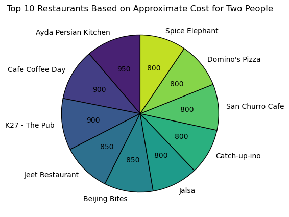

```python
top_costly = df.sort_values(by='approx_cost(for two people)', ascending=False).head(10)

plt.figure(figsize=(8, 5))
colors = sns.color_palette('viridis', len(top_costly))  # Use the 'viridis' color palette

plt.pie(top_costly['approx_cost(for two people)'], labels=top_costly['name'], autopct=lambda p: '{:.0f}'.format(p * sum(top_costly['approx_cost(for two people)']) / 100), startangle=90, colors=colors, wedgeprops={'edgecolor': 'black'})

plt.title('Top 10 Restaurants Based on Approximate Cost for Two People')
plt.show()
```

## Project Learning

By leveraging these insights, Zomato can tailor its marketing strategies, enhance customer experience, and optimize its partnerships with restaurants. By understanding customer preferences, spending habits, and satisfaction levels, Zomato can enhance its service offerings and drive growth on its platform. This analysis contributes to a deeper understanding of consumer behavior and helps in making data-driven decisions for improving service quality and customer satisfaction. This project underscores the importance of data-driven decision-making in the food delivery industry.